# 2025ag05644_assignment1

## 4.3 Baseline Model: Linear Regression from Scratch

```python
# ─────────────────────────────────────────────────────────
# 4.3 Baseline Model: Linear Regression from Scratch
#
# Implementation: Mini-batch Gradient Descent
# Model: y_hat = X @ w + b
# Loss:  MSE = (1/n) * sum((y_hat - y)^2)
# Update: w = w - lr * dw
#         b = b - lr * db
# ─────────────────────────────────────────────────────────

class LinearRegressionScratch:
    """
    Linear Regression from scratch using mini-batch gradient descent.

    Parameters
    ----------
    learning_rate : float
    n_epochs      : int   — number of full passes through training data
    batch_size    : int   — number of samples per mini-batch
    """

    def __init__(self, learning_rate=0.01, n_epochs=100, batch_size=512):
        self.lr          = learning_rate
        self.n_epochs    = n_epochs
        self.batch_size  = batch_size
        self.weights     = None
        self.bias        = None
        self.loss_history = []   # stores loss at end of each epoch

    def _initialize_weights(self, n_features):
        """Initialize weights to small random values, bias to 0."""
        self.weights = np.random.randn(n_features, 1) * 0.01
        self.bias    = 0.0

    def _forward(self, X):
        """Forward pass: compute predictions."""
        return X @ self.weights + self.bias   # (n, 1)

    def _compute_loss(self, y_hat, y):
        """
        Mean Squared Error — used as training loss.
        Note: RMSE (sqrt of MSE) is our primary evaluation metric
        and will be reported in Section 4.5. MSE is used here
        because it has simpler gradients than RMSE.
        """
        return np.mean((y_hat - y) ** 2)

    def _compute_gradients(self, X, y_hat, y):
        """
        Gradients of MSE w.r.t weights and bias.
        dL/dw = (2/n) * X.T @ (y_hat - y)
        dL/db = (2/n) * sum(y_hat - y)
        """
        n     = y.shape[0]
        error = y_hat - y                       # (n, 1)
        dw    = (2 / n) * (X.T @ error)        # (n_features, 1)
        db    = (2 / n) * np.sum(error)        # scalar
        return dw, db

    def fit(self, X, y):
        """
        Training loop:
        For each epoch:
            Shuffle data
            Split into mini-batches
            For each mini-batch:
                forward → loss → gradients → update weights
        Store epoch loss at end of each epoch.
        """
        n_samples  = X.shape[0]
        n_features = X.shape[1]
        self._initialize_weights(n_features)
        self.loss_history = []

        for epoch in range(self.n_epochs):
            # Shuffle training data at start of each epoch
            indices = np.random.permutation(n_samples)
            X_shuffled = X[indices]
            y_shuffled = y[indices]

            epoch_loss = 0.0
            n_batches  = 0

            # Mini-batch loop
            for start in range(0, n_samples, self.batch_size):
                end     = start + self.batch_size
                X_batch = X_shuffled[start:end]
                y_batch = y_shuffled[start:end]

                # Forward pass
                y_hat = self._forward(X_batch)

                # Compute batch loss
                batch_loss  = self._compute_loss(y_hat, y_batch)
                epoch_loss += batch_loss
                n_batches  += 1

                # Compute gradients
                dw, db = self._compute_gradients(X_batch, y_hat, y_batch)

                # Update weights: w = w - lr * grad
                self.weights -= self.lr * dw
                self.bias    -= self.lr * db

            # Store average loss across all batches for this epoch
            self.loss_history.append(epoch_loss / n_batches)

            if (epoch + 1) % 10 == 0:
                print(f"  Epoch {epoch+1:>4}/{self.n_epochs} "
                      f"| MSE Loss: {self.loss_history[-1]:.4f}")

        return self

    def predict(self, X):
        """Return predictions for input X."""
        return self._forward(X)


print("LinearRegressionScratch class defined.")
```

```
LinearRegressionScratch class defined.
```

```python
# ─────────────────────────────────────────────────────────
# Train Linear Regression
# ─────────────────────────────────────────────────────────

print("Training Linear Regression...")
start_baseline = time.time()

lin_reg = LinearRegressionScratch(
    learning_rate=0.01,
    n_epochs=100,
    batch_size=512
)
lin_reg.fit(X_train_scaled, y_train)

baseline_train_time = time.time() - start_baseline
print(f"\nTraining complete in {baseline_train_time:.2f}s")
```

```
Training Linear Regression...
  Epoch   10/100 | MSE Loss: 42.2032
  Epoch   20/100 | MSE Loss: 42.2035
  Epoch   30/100 | MSE Loss: 42.2055
  Epoch   40/100 | MSE Loss: 42.2105
  Epoch   50/100 | MSE Loss: 42.2092
  Epoch   60/100 | MSE Loss: 42.2040
  Epoch   70/100 | MSE Loss: 42.2081
  Epoch   80/100 | MSE Loss: 42.2043
  Epoch   90/100 | MSE Loss: 42.2095
  Epoch  100/100 | MSE Loss: 42.2039

Training complete in 6.64s
```

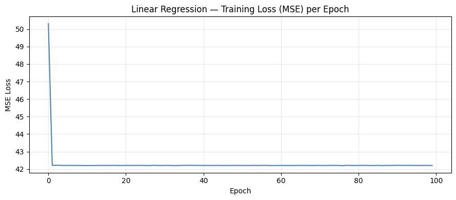

```
Initial loss : 50.3099
Final loss   : 42.2039
Improvement  : 8.1060
```

```python
# ─────────────────────────────────────────────────────────
# Plot Linear Regression Training Loss
# ─────────────────────────────────────────────────────────

plt.figure(figsize=(9, 4))
plt.plot(lin_reg.loss_history, color='steelblue', linewidth=1.5)
plt.title('Linear Regression — Training Loss (MSE) per Epoch')
plt.xlabel('Epoch')
plt.ylabel('MSE Loss')
plt.grid(True, alpha=0.3)
plt.tight_layout()
plt.show()

print(f"Initial loss : {lin_reg.loss_history[0]:.4f}")
print(f"Final loss   : {lin_reg.loss_history[-1]:.4f}")
print(f"Improvement  : {lin_reg.loss_history[0] - lin_reg.loss_history[-1]:.4f}")
```

## 4.4 Multi-Layer Perceptron (MLP) from Scratch

```python
# ─────────────────────────────────────────────────────────
# 4.4 Multi-Layer Perceptron (MLP) from Scratch
#
# Architecture : [14 → 64 → 32 → 1]
# Hidden layers: ReLU activation
# Output layer : Linear activation (no activation) — regression
# Loss         : MSE (RMSE reported in 4.5)
# Training     : Mini-batch gradient descent
# ─────────────────────────────────────────────────────────

class MLP:
    """
    Multi-Layer Perceptron for Regression, implemented from scratch.

    Parameters
    ----------
    layer_dims    : list  e.g. [14, 64, 32, 1]
                    [input_dim, hidden1, hidden2, ..., output_dim]
    learning_rate : float
    n_epochs      : int   — number of full passes through training data
    batch_size    : int   — number of samples per mini-batch
    """

    def __init__(self, layer_dims, learning_rate=0.01,
                 n_epochs=100, batch_size=512):
        self.layer_dims   = layer_dims
        self.lr           = learning_rate
        self.n_epochs     = n_epochs
        self.batch_size   = batch_size
        self.params       = {}   # W1, b1, W2, b2, ...
        self.loss_history = []
        self.L            = len(layer_dims) - 1  # number of layers

    # ──────────────────────────────────────────────────────
    # 1. Initialize Parameters
    # ──────────────────────────────────────────────────────
    def initialize_parameters(self):
        """
        Random initialisation — small random values for weights,
        bias initialised to 0.
        W[l] ~ N(0, 0.01)
        b[l] = 0
        """
        np.random.seed(42)
        for l in range(1, self.L + 1):
            n_in  = self.layer_dims[l - 1]
            n_out = self.layer_dims[l]
            self.params[f'W{l}'] = np.random.randn(n_in, n_out) * 0.01
            self.params[f'b{l}'] = np.zeros((1, n_out))

    # ──────────────────────────────────────────────────────
    # 2. Activation Functions
    # ──────────────────────────────────────────────────────
    @staticmethod
    def relu(Z):
        """ReLU: max(0, Z) — used for hidden layers."""
        return np.maximum(0, Z)

    @staticmethod
    def relu_derivative(Z):
        """Derivative of ReLU: 1 if Z > 0, else 0."""
        return (Z > 0).astype(float)

    # ──────────────────────────────────────────────────────
    # 3. Forward Propagation
    # ──────────────────────────────────────────────────────
    def forward_propagation(self, X):
        """
        Compute activations through all layers.
        Hidden layers : ReLU
        Output layer  : Linear (no activation) — regression
        Returns: y_hat (predictions), cache (Z and A per layer)
        """
        cache = {}
        A     = X
        cache['A0'] = X

        for l in range(1, self.L + 1):
            W = self.params[f'W{l}']
            b = self.params[f'b{l}']
            Z = A @ W + b                    # pre-activation

            if l < self.L:
                A = self.relu(Z)             # hidden layers: ReLU
            else:
                A = Z                        # output layer: linear

            cache[f'Z{l}'] = Z
            cache[f'A{l}'] = A

        return A, cache

    # ──────────────────────────────────────────────────────
    # 4. Loss
    # ──────────────────────────────────────────────────────
    @staticmethod
    def compute_loss(y_hat, y):
        """
        Mean Squared Error — used as training loss.
        Note: RMSE reported in Section 4.5 for interpretability.
        MSE used here because gradients are simpler than RMSE.
        """
        return np.mean((y_hat - y) ** 2)

    # ──────────────────────────────────────────────────────
    # 5. Backward Propagation
    # ──────────────────────────────────────────────────────
    def backward_propagation(self, y, cache):
        """
        Compute gradients using chain rule, layer by layer.
        Returns: grads dict with dW[l] and db[l] for each layer.

        Output layer (linear):
            dL/dZ_L = (2/n) * (y_hat - y)
        Hidden layers (ReLU):
            dZ[l] = dA[l] * ReLU'(Z[l])
        Parameter gradients:
            dW[l] = A[l-1].T @ dZ[l]
            db[l] = sum(dZ[l], axis=0)
        Propagate to previous layer:
            dA[l-1] = dZ[l] @ W[l].T
        """
        grads  = {}
        n      = y.shape[0]
        A_last = cache[f'A{self.L}']

        # Gradient of MSE w.r.t output — linear activation so dA = dZ
        dA = (2 / n) * (A_last - y)

        for l in reversed(range(1, self.L + 1)):
            Z_l    = cache[f'Z{l}']
            A_prev = cache[f'A{l-1}']
            W_l    = self.params[f'W{l}']

            if l == self.L:
                # Output layer: linear activation → dZ = dA
                dZ = dA
            else:
                # Hidden layer: apply ReLU derivative
                dZ = dA * self.relu_derivative(Z_l)

            # Parameter gradients
            grads[f'dW{l}'] = A_prev.T @ dZ
            grads[f'db{l}'] = np.sum(dZ, axis=0, keepdims=True)

            # Propagate gradient to previous layer
            dA = dZ @ W_l.T

        return grads

    # ──────────────────────────────────────────────────────
    # 6. Fit (Training Loop)
    # ──────────────────────────────────────────────────────
    def fit(self, X, y):
        """
        Training loop with mini-batch gradient descent.
        For each epoch:
            Shuffle data
            Split into mini-batches
            For each mini-batch:
                forward → loss → backward → update weights
        Store average epoch loss in loss_history.
        """
        n_samples = X.shape[0]
        self.initialize_parameters()
        self.loss_history = []

        for epoch in range(self.n_epochs):
            # Shuffle data at start of each epoch
            indices    = np.random.permutation(n_samples)
            X_shuffled = X[indices]
            y_shuffled = y[indices]

            epoch_loss = 0.0
            n_batches  = 0

            for start in range(0, n_samples, self.batch_size):
                end     = start + self.batch_size
                X_batch = X_shuffled[start:end]
                y_batch = y_shuffled[start:end]

                # Forward pass
                y_hat, cache = self.forward_propagation(X_batch)

                # Compute batch loss
                batch_loss  = self.compute_loss(y_hat, y_batch)
                epoch_loss += batch_loss
                n_batches  += 1

                # Backward pass
                grads = self.backward_propagation(y_batch, cache)

                # Update weights: w = w - lr * grad
                for l in range(1, self.L + 1):
                    self.params[f'W{l}'] -= self.lr * grads[f'dW{l}']
                    self.params[f'b{l}'] -= self.lr * grads[f'db{l}']

            # Store average loss across all batches for this epoch
            self.loss_history.append(epoch_loss / n_batches)

            if (epoch + 1) % 10 == 0:
                print(f"  Epoch {epoch+1:>4}/{self.n_epochs} "
                      f"| MSE Loss: {self.loss_history[-1]:.4f}")

        return self

    # ──────────────────────────────────────────────────────
    # 7. Predict
    # ──────────────────────────────────────────────────────
    def predict(self, X):
        """Return predictions for input X."""
        y_hat, _ = self.forward_propagation(X)
        return y_hat


print("MLP class defined.")
```

```
MLP class defined.
```

```python
# ─────────────────────────────────────────────────────────
# Train MLP
# Architecture: [14 input → 64 → 32 → 1 output]
# ─────────────────────────────────────────────────────────

n_features   = X_train_scaled.shape[1]
ARCHITECTURE = [n_features, 64, 32, 1]

print(f"MLP Architecture : {ARCHITECTURE}")
print(f"  Layer 1 (hidden): {ARCHITECTURE[0]} → {ARCHITECTURE[1]}, ReLU")
print(f"  Layer 2 (hidden): {ARCHITECTURE[1]} → {ARCHITECTURE[2]}, ReLU")
print(f"  Layer 3 (output): {ARCHITECTURE[2]} → {ARCHITECTURE[3]}, Linear")
print()
print("Training MLP...")

start_mlp = time.time()

mlp = MLP(
    layer_dims=ARCHITECTURE,
    learning_rate=0.01,
    n_epochs=100,
    batch_size=512
)
mlp.fit(X_train_scaled, y_train)

mlp_train_time = time.time() - start_mlp
print(f"\nTraining complete in {mlp_train_time:.2f}s")
```

```
MLP Architecture : [14, 64, 32, 1]
  Layer 1 (hidden): 14 → 64, ReLU
  Layer 2 (hidden): 64 → 32, ReLU
  Layer 3 (output): 32 → 1, Linear

Training MLP...
  Epoch   10/100 | MSE Loss: 3.5433
  Epoch   20/100 | MSE Loss: 3.3302
  Epoch   30/100 | MSE Loss: 3.2973
  Epoch   40/100 | MSE Loss: 3.5710
  Epoch   50/100 | MSE Loss: 3.3166
  Epoch   60/100 | MSE Loss: 3.2113
  Epoch   70/100 | MSE Loss: 3.1743
  Epoch   80/100 | MSE Loss: 3.1546
  Epoch   90/100 | MSE Loss: 3.1548
  Epoch  100/100 | MSE Loss: 3.1086

Training complete in 57.88s
```

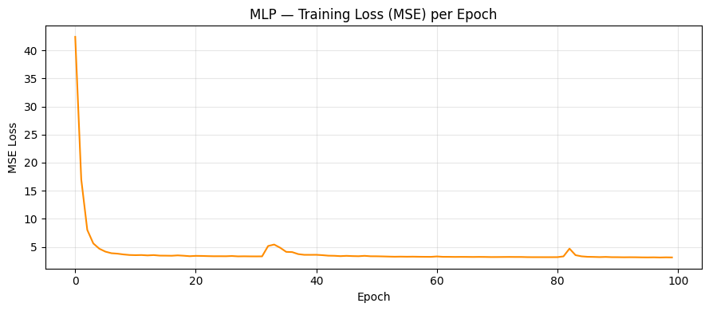

```
Initial loss : 42.4265
Final loss   : 3.1086
Improvement  : 39.3179
```

```python
# ─────────────────────────────────────────────────────────
# Plot MLP Training Loss
# ─────────────────────────────────────────────────────────

plt.figure(figsize=(9, 4))
plt.plot(mlp.loss_history, color='darkorange', linewidth=1.5)
plt.title('MLP — Training Loss (MSE) per Epoch')
plt.xlabel('Epoch')
plt.ylabel('MSE Loss')
plt.grid(True, alpha=0.3)
plt.tight_layout()
plt.show()

print(f"Initial loss : {mlp.loss_history[0]:.4f}")
print(f"Final loss   : {mlp.loss_history[-1]:.4f}")
print(f"Improvement  : {mlp.loss_history[0] - mlp.loss_history[-1]:.4f}")
```

## 4.5 Evaluation & Comparison

```python
# ─────────────────────────────────────────────────────────
# 4.5 Evaluation & Comparison
#
# Metrics computed from scratch (no sklearn):
#   MSE  = (1/n) * sum((y_hat - y)²)
#   RMSE = sqrt(MSE)
#   MAE  = (1/n) * sum(|y_hat - y|)
#   R²   = 1 - (SS_res / SS_tot)
# ─────────────────────────────────────────────────────────

def compute_metrics(y_true, y_pred):
    """
    Compute MSE, RMSE, MAE, R² from scratch.
    Parameters
    ----------
    y_true : array of actual values
    y_pred : array of predicted values
    Returns dict of metrics.
    """
    y_true = y_true.flatten()
    y_pred = y_pred.flatten()

    mse    = np.mean((y_pred - y_true) ** 2)
    rmse   = np.sqrt(mse)
    mae    = np.mean(np.abs(y_pred - y_true))
    ss_res = np.sum((y_true - y_pred) ** 2)
    ss_tot = np.sum((y_true - np.mean(y_true)) ** 2)
    r2     = 1 - (ss_res / ss_tot)

    return {'MSE': mse, 'RMSE': rmse, 'MAE': mae, 'R2': r2}


# ── Predictions ───────────────────────────────────────────
y_pred_lr_train  = lin_reg.predict(X_train_scaled)
y_pred_lr_test   = lin_reg.predict(X_test_scaled)
y_pred_mlp_train = mlp.predict(X_train_scaled)
y_pred_mlp_test  = mlp.predict(X_test_scaled)

# ── Compute Metrics ───────────────────────────────────────
lr_train_metrics  = compute_metrics(y_train, y_pred_lr_train)
lr_test_metrics   = compute_metrics(y_test,  y_pred_lr_test)
mlp_train_metrics = compute_metrics(y_train, y_pred_mlp_train)
mlp_test_metrics  = compute_metrics(y_test,  y_pred_mlp_test)

# ── Print Results Table ───────────────────────────────────
print("=" * 62)
print(f"{'Metric':<8} {'LR Train':>10} {'LR Test':>10} "
      f"{'MLP Train':>10} {'MLP Test':>10}")
print("-" * 62)
for m in ['MSE', 'RMSE', 'MAE', 'R2']:
    print(f"{m:<8} {lr_train_metrics[m]:>10.4f} "
          f"{lr_test_metrics[m]:>10.4f} "
          f"{mlp_train_metrics[m]:>10.4f} "
          f"{mlp_test_metrics[m]:>10.4f}")
print("=" * 62)
print(f"\nPrimary metric (RMSE) — Test set:")
print(f"  Linear Regression : ${lr_test_metrics['RMSE']:.4f} avg error per ride")
print(f"  MLP               : ${mlp_test_metrics['RMSE']:.4f} avg error per ride")
```

```
==============================================================
Metric     LR Train    LR Test  MLP Train   MLP Test
--------------------------------------------------------------
MSE         42.2055    42.4922     3.2068     3.3080
RMSE         6.4966     6.5186     1.7908     1.8188
MAE          5.1727     5.1883     1.2090     1.2179
R2           0.5141     0.5134     0.9631     0.9621
==============================================================

Primary metric (RMSE) — Test set:
  Linear Regression : $6.5186 avg error per ride
  MLP               : $1.8188 avg error per ride
```

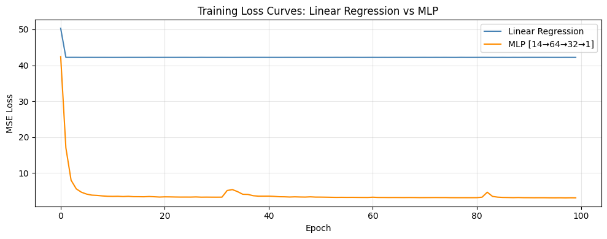

```python
# ─────────────────────────────────────────────────────────
# Plot 1: Training Loss Curves — Baseline vs MLP
# ─────────────────────────────────────────────────────────

plt.figure(figsize=(10, 4))
plt.plot(lin_reg.loss_history, label='Linear Regression',
         color='steelblue', linewidth=1.5)
plt.plot(mlp.loss_history, label='MLP [14→64→32→1]',
         color='darkorange', linewidth=1.5)
plt.title('Training Loss Curves: Linear Regression vs MLP')
plt.xlabel('Epoch')
plt.ylabel('MSE Loss')
plt.legend()
plt.grid(True, alpha=0.3)
plt.tight_layout()
plt.show()
```

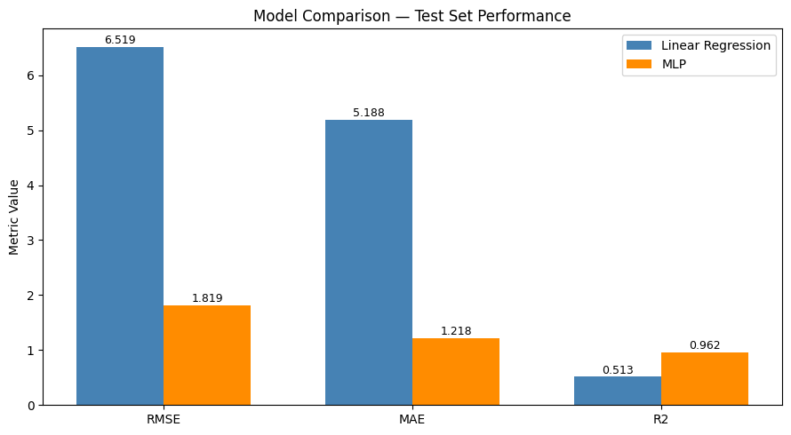

```python
# ─────────────────────────────────────────────────────────
# Plot 2: Performance Comparison Bar Chart — Test Set
# ─────────────────────────────────────────────────────────

metrics_list = ['RMSE', 'MAE', 'R2']
lr_vals      = [lr_test_metrics[m]  for m in metrics_list]
mlp_vals     = [mlp_test_metrics[m] for m in metrics_list]

x     = np.arange(len(metrics_list))
width = 0.35

fig, ax = plt.subplots(figsize=(9, 5))
bars1 = ax.bar(x - width/2, lr_vals,  width,
               label='Linear Regression', color='steelblue')
bars2 = ax.bar(x + width/2, mlp_vals, width,
               label='MLP', color='darkorange')

ax.set_title('Model Comparison — Test Set Performance')
ax.set_xticks(x)
ax.set_xticklabels(metrics_list)
ax.set_ylabel('Metric Value')
ax.legend()

for bar in bars1:
    ax.text(bar.get_x() + bar.get_width()/2,
            bar.get_height() + 0.01,
            f'{bar.get_height():.3f}',
            ha='center', va='bottom', fontsize=9)
for bar in bars2:
    ax.text(bar.get_x() + bar.get_width()/2,
            bar.get_height() + 0.01,
            f'{bar.get_height():.3f}',
            ha='center', va='bottom', fontsize=9)

plt.tight_layout()
plt.show()
```

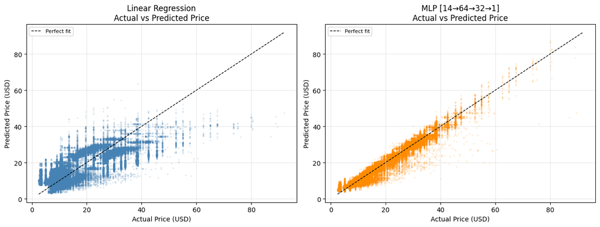

```python
# ─────────────────────────────────────────────────────────
# Plot 3: Actual vs Predicted — domain specific plot
# ─────────────────────────────────────────────────────────

fig, axes = plt.subplots(1, 2, figsize=(13, 5))
y_true_flat = y_test.flatten()

for ax, y_pred, title, color in zip(
    axes,
    [y_pred_lr_test.flatten(), y_pred_mlp_test.flatten()],
    ['Linear Regression', 'MLP [14→64→32→1]'],
    ['steelblue', 'darkorange']
):
    ax.scatter(y_true_flat, y_pred, alpha=0.1, s=3, color=color)
    lims = [min(y_true_flat.min(), y_pred.min()),
            max(y_true_flat.max(), y_pred.max())]
    ax.plot(lims, lims, 'k--', linewidth=1, label='Perfect fit')
    ax.set_title(f'{title}\nActual vs Predicted Price')
    ax.set_xlabel('Actual Price (USD)')
    ax.set_ylabel('Predicted Price (USD)')
    ax.legend(fontsize=8)
    ax.grid(True, alpha=0.3)

plt.tight_layout()
plt.show()
```

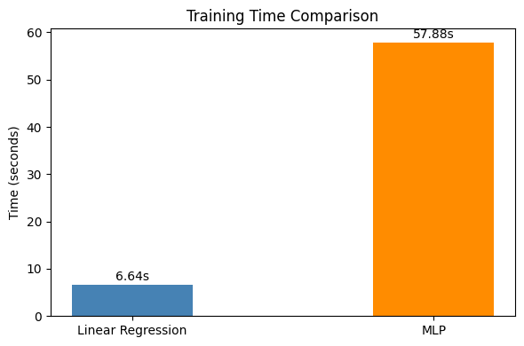

```python
# ─────────────────────────────────────────────────────────
# Plot 4: Training Time Comparison
# ─────────────────────────────────────────────────────────

fig, ax = plt.subplots(figsize=(6, 4))
models = ['Linear Regression', 'MLP']
times  = [baseline_train_time, mlp_train_time]
colors = ['steelblue', 'darkorange']

bars = ax.bar(models, times, color=colors, width=0.4)
for bar, t in zip(bars, times):
    ax.text(bar.get_x() + bar.get_width()/2,
            bar.get_height() + 0.3,
            f'{t:.2f}s', ha='center', va='bottom', fontsize=10)

ax.set_title('Training Time Comparison')
ax.set_ylabel('Time (seconds)')
plt.tight_layout()
plt.show()
```

## Analysis

The MLP significantly outperformed Linear Regression across all metrics on this ride price regression task. On the test set, MLP achieved an RMSE of $1.82 compared to $6.52 for Linear Regression, a 3.6x improvement, and explained 96.2% of price variance (R2=0.962) versus 51.3% for the baseline.

The trade-off is computational cost. Linear Regression trained in 6.64 seconds while MLP required 57.88 seconds, which is 8.7x slower, due to backpropagation through two hidden layers and cache storage for all intermediate activations. At production scale with millions of rides, this cost difference becomes significant. However for the accuracy gains achieved here, the MLP is clearly the better model for ride price prediction.

## get_assignment_results()

```python
# ─────────────────────────────────────────────────────────
# get_assignment_results()
# Returns a dictionary summarising all assignment results.
# ─────────────────────────────────────────────────────────

def get_assignment_results():
    """
    Returns a dictionary summarising all assignment results.
    """
    results = {
        # ── Dataset Info ──────────────────────────────────
        'dataset_name'   : 'Uber and Lyft Dataset Boston, MA',
        'n_samples'      : len(df),
        'n_features'     : len(FEATURES),
        'problem_type'   : 'Regression',
        'primary_metric' : 'RMSE (Root Mean Squared Error)',

        # ── Baseline Model ────────────────────────────────
        'baseline_model': {
            'name'              : 'Linear Regression (from scratch)',
            'learning_rate'     : lin_reg.lr,
            'n_epochs'          : lin_reg.n_epochs,
            'batch_size'        : lin_reg.batch_size,
            'train_MSE'         : round(lr_train_metrics['MSE'],  4),
            'train_RMSE'        : round(lr_train_metrics['RMSE'], 4),
            'train_MAE'         : round(lr_train_metrics['MAE'],  4),
            'train_R2'          : round(lr_train_metrics['R2'],   4),
            'test_MSE'          : round(lr_test_metrics['MSE'],   4),
            'test_RMSE'         : round(lr_test_metrics['RMSE'],  4),
            'test_MAE'          : round(lr_test_metrics['MAE'],   4),
            'test_R2'           : round(lr_test_metrics['R2'],    4),
            'training_time_sec' : round(baseline_train_time,      4),
        },

        # ── MLP Model ─────────────────────────────────────
        'mlp_model': {
            'name'              : 'MLP (from scratch)',
            'architecture'      : mlp.layer_dims,
            'hidden_activation' : 'ReLU',
            'output_activation' : 'Linear',
            'learning_rate'     : mlp.lr,
            'n_epochs'          : mlp.n_epochs,
            'batch_size'        : mlp.batch_size,
            'train_MSE'         : round(mlp_train_metrics['MSE'],  4),
            'train_RMSE'        : round(mlp_train_metrics['RMSE'], 4),
            'train_MAE'         : round(mlp_train_metrics['MAE'],  4),
            'train_R2'          : round(mlp_train_metrics['R2'],   4),
            'test_MSE'          : round(mlp_test_metrics['MSE'],   4),
            'test_RMSE'         : round(mlp_test_metrics['RMSE'],  4),
            'test_MAE'          : round(mlp_test_metrics['MAE'],   4),
            'test_R2'           : round(mlp_test_metrics['R2'],    4),
            'training_time_sec' : round(mlp_train_time,            4),
        },
    }
    return results


# ── Call and display ──────────────────────────────────────
results = get_assignment_results()

print("=" * 55)
print(" ASSIGNMENT RESULTS SUMMARY")
print("=" * 55)
print(f"  Dataset       : {results['dataset_name']}")
print(f"  Samples       : {results['n_samples']:,}")
print(f"  Features      : {results['n_features']}")
print(f"  Problem type  : {results['problem_type']}")
print(f"  Primary metric: {results['primary_metric']}")
print()
print("  BASELINE (Linear Regression)")
print("  " + "-" * 40)
b = results['baseline_model']
print(f"    Learning rate : {b['learning_rate']}")
print(f"    Epochs        : {b['n_epochs']}")
print(f"    Batch size    : {b['batch_size']}")
print(f"    Train RMSE    : ${b['train_RMSE']}")
print(f"    Test  RMSE    : ${b['test_RMSE']}")
print(f"    Train R2      : {b['train_R2']}")
print(f"    Test  R2      : {b['test_R2']}")
print(f"    Training time : {b['training_time_sec']}s")
print()
print("  MLP")
print("  " + "-" * 40)
m = results['mlp_model']
print(f"    Architecture  : {m['architecture']}")
print(f"    Hidden act    : {m['hidden_activation']}")
print(f"    Output act    : {m['output_activation']}")
print(f"    Learning rate : {m['learning_rate']}")
print(f"    Epochs        : {m['n_epochs']}")
print(f"    Batch size    : {m['batch_size']}")
print(f"    Train RMSE    : ${m['train_RMSE']}")
print(f"    Test  RMSE    : ${m['test_RMSE']}")
print(f"    Train R2      : {m['train_R2']}")
print(f"    Test  R2      : {m['test_R2']}")
print(f"    Training time : {m['training_time_sec']}s")
print("=" * 55)
```

```
=======================================================
 ASSIGNMENT RESULTS SUMMARY
=======================================================
  Dataset       : Uber and Lyft Dataset Boston, MA
  Samples       : 637,628
  Features      : 14
  Problem type  : Regression
  Primary metric: RMSE (Root Mean Squared Error)

  BASELINE (Linear Regression)
  ----------------------------------------
    Learning rate : 0.01
    Epochs        : 100
    Batch size    : 512
    Train RMSE    : $6.4966
    Test  RMSE    : $6.5186
    Train R2      : 0.5141
    Test  R2      : 0.5134
    Training time : 6.6394s

  MLP
  ----------------------------------------
    Architecture  : [14, 64, 32, 1]
    Hidden act    : ReLU
    Output act    : Linear
    Learning rate : 0.01
    Epochs        : 100
    Batch size    : 512
    Train RMSE    : $1.7908
    Test  RMSE    : $1.8188
    Train R2      : 0.9631
    Test  R2      : 0.9621
    Training time : 57.8824s
=======================================================
```